# Reproducible Research: Peer Assessment 1

## Loading and preprocessing the data

The source data is provided via clone.

##### Show any code that is needed to:

1. Load the data (i.e. read.csv())
2. Process/transform the data (if necessary) into a format suitable for your analysis

```r
unzip("./activity.zip") # contains activity.csv
data <- read.csv("./activity.csv")

# remove missing rows
df <- data[complete.cases(data), ]

# change the date column to date objects for easier processing
df$date <-as.Date(as.character(df$date), format="%Y-%m-%d")

# create some date vars for use in descriptions later on
mindate <- min(df$date)
maxdate <- max(df$date)
```

Performing a bit of preliminary exploration is not required but helpful.

```r
names(df)
```

```
## [1] "steps"    "date"     "interval"
```

```r
summary(df)
```

```
##      steps             date               interval
##  Min.   :  0.00   Min.   :2012-10-02   Min.   :   0.0
##  1st Qu.:  0.00   1st Qu.:2012-10-16   1st Qu.: 588.8
##  Median :  0.00   Median :2012-10-29   Median :1177.5
##  Mean   : 37.38   Mean   :2012-10-30   Mean   :1177.5
##  3rd Qu.: 12.00   3rd Qu.:2012-11-16   3rd Qu.:1766.2
##  Max.   :806.00   Max.   :2012-11-29   Max.   :2355.0
```

```r
str(df)
```

```
## 'data.frame':    15264 obs. of  3 variables:
##  $ steps   : int  0 0 0 0 0 0 0 0 0 0 ...
##  $ date    : Date, format: "2012-10-02" "2012-10-02" ...
##  $ interval: int  0 5 10 15 20 25 30 35 40 45 ...
```

## What is mean total number of steps taken per day?

##### For this part of the assignment, you can ignore the missing values in the dataset.

1. Calculate the total number of steps taken per day

```r
steps.per.day <- tapply(df$steps, INDEX=df$date, FUN=sum, na.rm=TRUE)
```

2. Make a histogram of the total number of steps taken each day

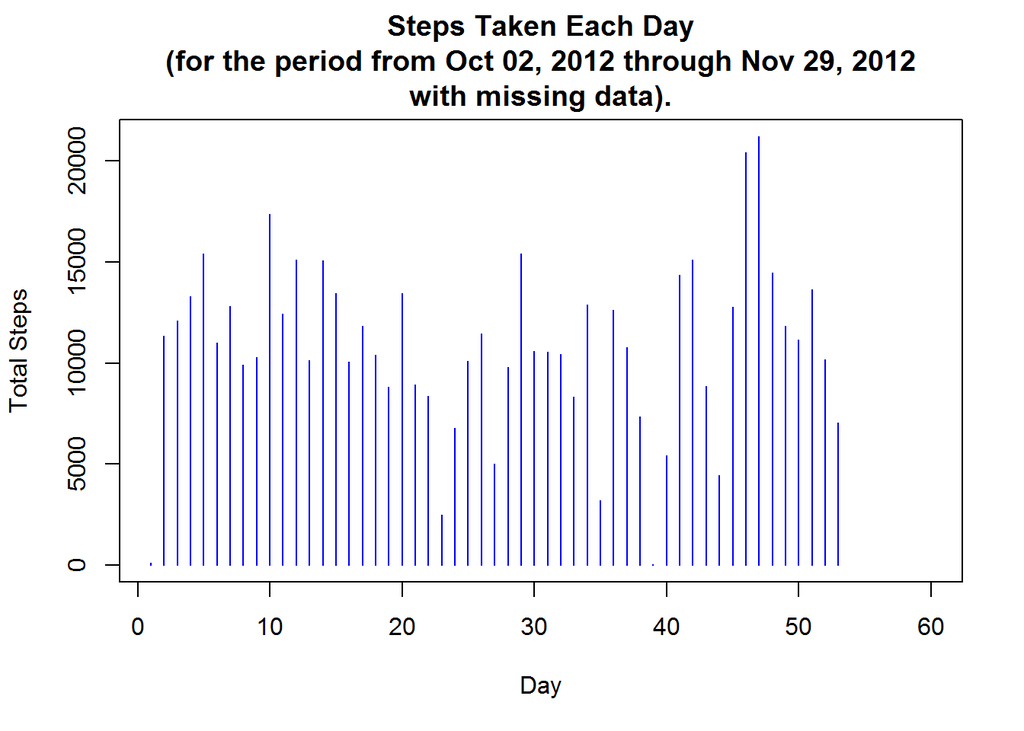

```r
# create a description for the histogram
desc <- paste(
                "Steps Taken Each Day\n(for the period from ",
                as.character(mindate, format="%b %d, %Y"),
                " through ",
                as.character(maxdate, format="%b %d, %Y"),
                "\nwith missing data).",
                sep=""
        )

# render the plot
plot(
        steps.per.day,
        main=desc,
        type="h",
        col="blue",
        xlab="Day",
        ylab="Total Steps",
        xlim=range(1,60)
)
```

3. Calculate and report the mean and median of the total number of steps taken per day

```r
mu <- round(mean(steps.per.day, na.rm=TRUE),2)
mede <- round(median(steps.per.day, na.rm=TRUE),2)
```

The mean number of total steps per day is 10766.19 and the median is 10765.

## What is the average daily activity pattern?

1. Make a time series plot (i.e. type = “l”) of the 5-minute interval (x-axis) and the average number of steps taken, averaged across all days (y-axis)

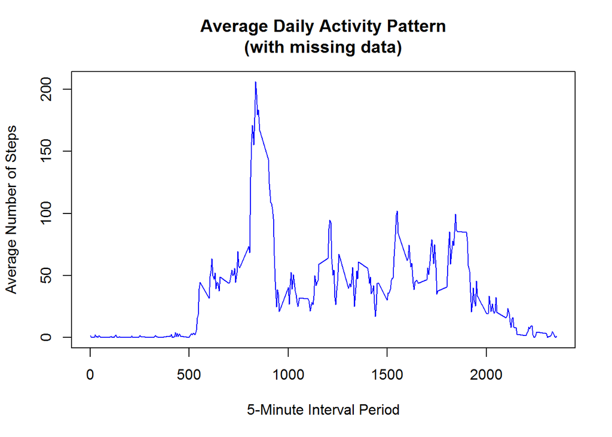

```r
# calc aggregate of the mean of the number of steps for five minute intervals
interval <- aggregate(steps ~ interval, data = df, mean)

# add a meaningful name to the mean column of the interval datafram
names(interval)[2] <- "interval_mean"

# get the max interval
maxitem <- interval[interval$interval_mean==max(interval$interval_mean),]

# generate the plot
plot(
        x = interval$interval,
        y = interval$interval_mean,
        type = "l",
        main = "Average Daily Activity Pattern\n(with missing data)",
        xlab = "5-Minute Interval Period",
        ylab = "Average Number of Steps",
        col = "blue"
)
```

2. Which 5-minute interval, on average across all the days in the dataset, contains the maximum number of steps?

Interval 835 has the maximum average number of steps of 206.17.

## Imputing missing values

Note that there are a number of days/intervals where there are missing values (coded as NA). The presence of missing days may introduce bias into some calculations or summaries of the data.

1. Calculate and report the total number of missing values in the dataset (i.e. the total number of rows with NAs)

```r
missing_values <- sum(!complete.cases(data))
```

There are 2304 rows with missing data (NA values) in the source data.

2. Devise a strategy for filling in all of the missing values in the dataset. The strategy does not need to be sophisticated. For example, you could use the mean/median for that day, or the mean for that 5-minute interval, etc. An acceptable plan for completing the missing data is to use the mean for the relevant interval.
3. Create a new dataset that is equal to the original dataset but with the missing data filled in.

```r
# replace the NA values
df2<- replace(data, is.na(data), interval$interval_mean)

# change the date column to date objects for easier processing
df2$date <-as.Date(as.character(df2$date), format="%Y-%m-%d")

# create a new dataset using df2
steps.per.day2 <- tapply(df2$steps, INDEX=df2$date, FUN=sum, na.rm=TRUE)
```

4. Make a histogram of the total number of steps taken each day and Calculate and report the mean and median total number of steps taken per day. Do these values differ from the estimates from the first part of the assignment? What is the impact of imputing missing data on the estimates of the total daily number of steps?

[figure not shown]

```r
# create a description for the histogram
desc2 <- paste(
                "Steps Taken Each Day\n(for the period from ",
                as.character(mindate, format="%b %d, %Y"),
                " through ",
                as.character(maxdate, format="%b %d, %Y"),
                "\nwith imputed data for NA values).",
                sep=""
        )

# render the plot
plot(
        steps.per.day2,
        main=desc2,
        type="h",
        col="blue",
        xlab="Day",
        ylab="Total Steps",
        xlim=range(1,60)
)
```

```r
# calculate the corrected mu and med and percentage differences
mu2 <- round(mean(steps.per.day2, na.rm=TRUE),2)
mede2 <- round(median(steps.per.day2, na.rm=TRUE),2)

mu_dif <- paste(round(100*(mu2 - mu)/ mu2, 2), "%", sep="")
mede_dif <- paste(round(100*(mede2 - mede)/ mede2, 2), "%", sep="")
```

The corrected mean number of total steps per day is 10766.19 and the corrected median is 10766.19. The ‘corrected’ mean should not have any difference from the source data because we substituted the mean for missing items. The impact is not significant for median which differs by only 0.01%. The difference in median was introduced by using the mean instead of median in the missing data. As a result of this brief analysis, it does not appear that the correction has a significant impact on the mean or median.

## Are there differences in activity patterns between weekdays and weekends?

For this part the weekdays() function may be of some help here. Use the dataset with the filled-in missing values for this part.

1. Create a new factor variable in the dataset with two levels - “weekday” and “weekend” indicating whether a given date is a weekday or weekend day.

```r
# create a function to set weekday or not
daytype <- function(date) {
        if (weekdays(as.Date(date)) %in% c("Saturday", "Sunday")) {
                "Weekend"
        } else {
                "Weekday"
        }
}

# create a new column using the 'daytype' function
df2$daytype <- as.factor(sapply(df2$date, daytype))
```

2. Make a panel plot containing a time series plot (i.e. type = “l”) of the 5-minute interval (x-axis) and the average number of steps taken, averaged across all weekday days or weekend days (y-axis). See the README file in the GitHub repository to see an example of what this plot should look like using simulated data.

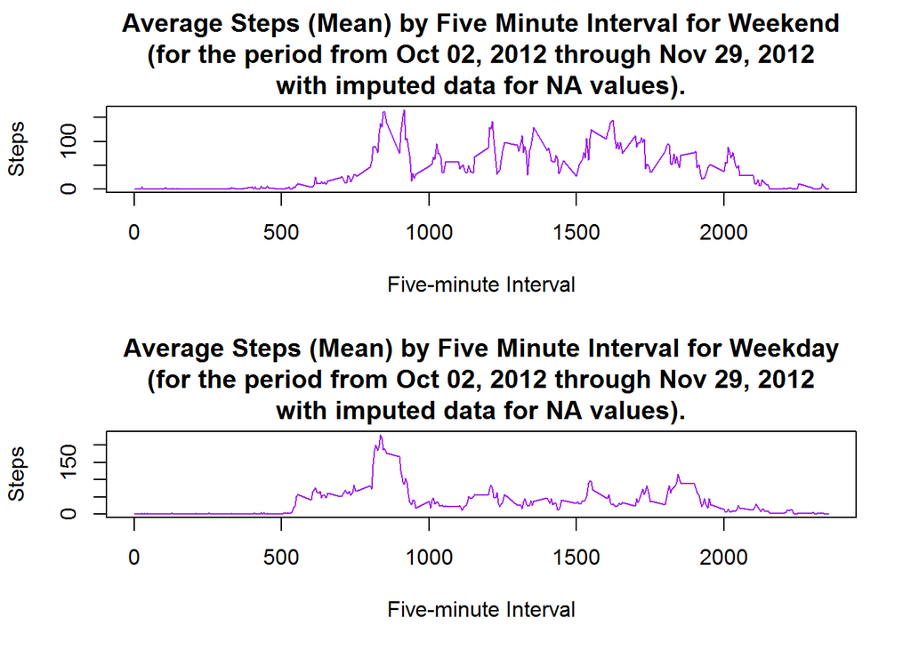

```r
# create the panel plot
par(mfrow=c(2,1))
for (set in c("Weekend","Weekday")) {
    desc3 <- paste(
                "Average Steps (Mean) by Five Minute Interval for ",
                set,
                "\n(for the period from ",
                 as.character(mindate, format="%b %d, %Y"),
                " through ",
                as.character(maxdate, format="%b %d, %Y"),
                "\nwith imputed data for NA values).",
                sep=""
           )

    plotset <- aggregate(steps ~ interval, data=df2, subset=df2$daytype==set, FUN=mean)
    plot(
        plotset,
        type = "l",
        col="purple",
        main=desc3,
        xlab="Five-minute Interval",
        ylab="Steps"
     )
}
```